# STA 141A Fall 2022: Homework 3

For all the hypothesis tests in this assignment, you should test against the significance level 0.01.

# Multiple linear regression: Simulated data

```r
library(ggplot2)
library(magrittr)
library(dplyr)
library(ISLR)
library(GGally)
```

```r
cor_answer <- function(x1, x2) {
  num <- cor(x1, x2)
  data <- cbind(x1, x2) %>% as.data.frame()

  plot <- ggplot(
    data,
    aes(
      x = x1,
      y = x2
    )
  ) +
    geom_point()

  list(
    cor = num,
    plot = plot
  )
}

model_answer <- function(model) {
  par(mfrow = c(2, 2))
  list(
    model = model,
    s = model %>% sigma() %>% sqrt(),
    summary = model %>% summary(),
    plot = model %>% plot()
  )
}
```

1. Run the following code to create the vectors `x1`, `x2`, and `y`.

```r
set.seed(1)
n <- 100
x1 <- runif(n)
x2 <- runif(n, 10, 20)
y <- 2 + 2 * x1 + 0.3 * x2 + rnorm(n)
```

1. (1 pts) The last line of the code above corresponds to creating a linear model in which `y` is a function of `x1` and `x2`. Write out the form of the linear model. What are the values of the regression coefficients $\beta_0$, $\beta_1$ and $\beta_2$? What is the value of $\sigma^2$?

$$y = \beta_0 + \beta_1(x1) + \beta_2(x2) + \varepsilon$$
$$\beta_0 = 2$$
$$\beta_1 = 2$$
$$\beta_2 = 0.3$$
$$\sigma^2 = 1$$

2. (1 pts) Use the function `cor()` to calculate the correlation coefficient between `x1` and `x2`. Create a scatter plot using `ggplot2` displaying the relationship between the variables `x1` and `x2`. What can you say about the direction and strength of their relationship?

```r
cor_answer(x1, x2)
```

```
## $cor
## [1] 0.01703215
##
## $plot
```

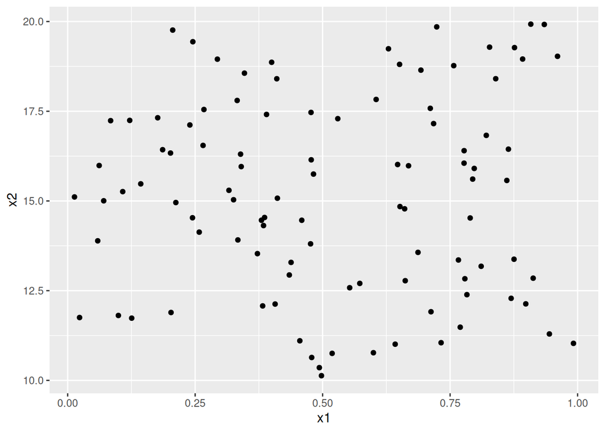

- There doesn’t seem to be any correlation between x1 and x2
3. (2 pts) Fit a least squares regression to predict `y` using `x1` and `x2`. Describe the obtained results. What are the values of $\hat\beta_0$, $\hat\beta_1$ and $\hat\beta_2$? How do these relate to the true values of $\beta_0$, $\beta_1$ and $\beta_2$? What is the value of $s = ((n - p - 1)^{-1}\sum_{i=1}^n(y_i-\hat y_i)^2)^{0.5}$ and how does it relate to the true value of $\sigma^2$? Can you reject the null hypothesis $H_0:\beta_1=0$? How about the null hypothesis $H_0:\beta_2=0$?

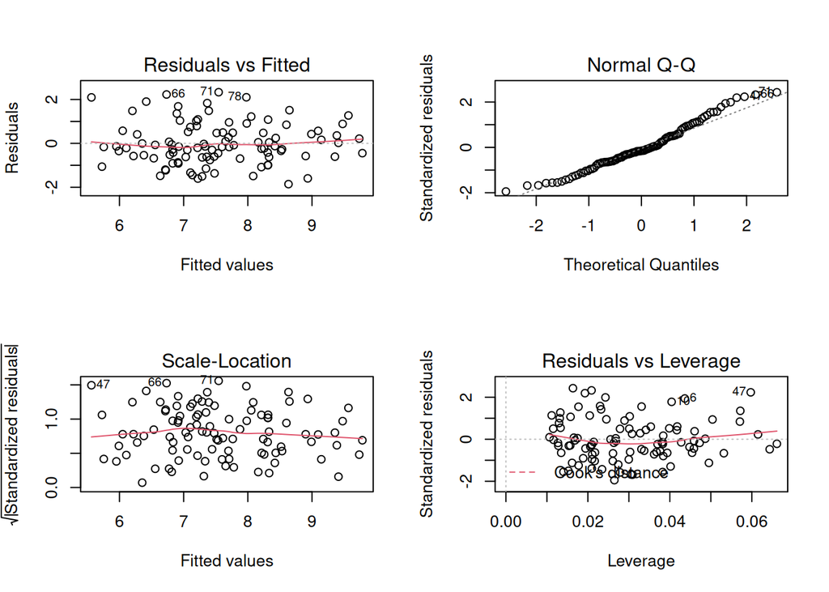

```
## $model
##
## Call:
## lm(formula = y ~ x1 + x2)
##
## Coefficients:
## (Intercept)           x1           x2
##      1.9763       1.9307       0.3014
##
##
## $s
## [1] 0.9836238
##
## $summary
##
## Call:
## lm(formula = y ~ x1 + x2)
##
## Residuals:
##     Min      1Q  Median      3Q     Max
## -1.8579 -0.6167 -0.1432  0.5352  2.3318
##
## Coefficients:
##             Estimate Std. Error t value Pr(>|t|)
## (Intercept)  1.97628    0.57973   3.409 0.000951 ***
## x1           1.93074    0.36345   5.312 6.89e-07 ***
## x2           0.30144    0.03578   8.425 3.33e-13 ***
## ---
## Signif. codes:  0 '***' 0.001 '**' 0.01 '*' 0.05 '.' 0.1 ' ' 1
##
## Residual standard error: 0.9675 on 97 degrees of freedom
## Multiple R-squared:  0.5095, Adjusted R-squared:  0.4994
## F-statistic: 50.38 on 2 and 97 DF,  p-value: 9.917e-16
##
##
## $plot
## NULL
```

```r
model_answer(lm(y ~ x1 + x2))
```

- All of these estimated quantities are very close to their true values.
- We have evidence to reject the null hypothesis for both tests.
4. (2 pts) Now fit a least squares regression to predict `y` using only `x1`. Comment on your results. What are the values of $\hat\beta_0$ and $\hat\beta_1$? How do these relate to the true values of $\beta_0$ and $\beta_1$? What is the value of $s$ and how does it relate to the true value of $\sigma^2$? Can you reject the null hypothesis $H_0:\beta_1=0$?

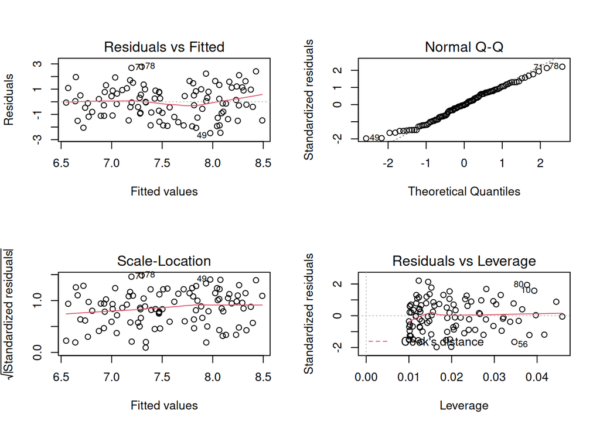

```
## $model
##
## Call:
## lm(formula = y ~ x1)
##
## Coefficients:
## (Intercept)           x1
##       6.523        1.983
##
##
## $s
## [1] 1.125477
##
## $summary
##
## Call:
## lm(formula = y ~ x1)
##
## Residuals:
##      Min       1Q   Median       3Q      Max
## -2.48228 -0.97125 -0.03059  0.93666  2.78169
##
## Coefficients:
##             Estimate Std. Error t value Pr(>|t|)
## (Intercept)   6.5235     0.2770  23.548  < 2e-16 ***
## x1            1.9829     0.4758   4.168 6.64e-05 ***
## ---
## Signif. codes:  0 '***' 0.001 '**' 0.01 '*' 0.05 '.' 0.1 ' ' 1
##
## Residual standard error: 1.267 on 98 degrees of freedom
## Multiple R-squared:  0.1506, Adjusted R-squared:  0.1419
## F-statistic: 17.37 on 1 and 98 DF,  p-value: 6.638e-05
##
##
## $plot
## NULL
```

```r
model_answer(lm(y ~ x1))
```

- In this model the estimated coefficient for $\beta_0$, is much larger than its true value  
  all others are pretty close to their true values.
- Here we have evidence to reject the null hypothesis for this test
  $$H_0: \beta_1 = 0$$
5. (2 pts) Now fit a least squares regression to predict `y` using only `x2`. Comment on your results. What are the values of $\hat\beta_0$ and $\hat\beta_2$? How do these relate to the true values of $\beta_0$ and $\beta_2$? What is the value of $s$ and does it relate to the true value of $\sigma^2$? Can you reject the null hypothesis $H_0:\beta_2=0$?

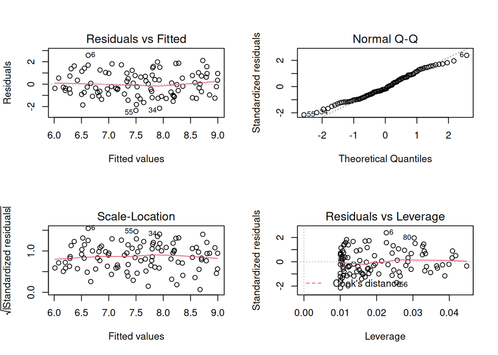

```
## $model
##
## Call:
## lm(formula = y ~ x2)
##
## Coefficients:
## (Intercept)           x2
##      2.9270       0.3047
##
##
## $s
## [1] 1.045782
##
## $summary
##
## Call:
## lm(formula = y ~ x2)
##
## Residuals:
##     Min      1Q  Median      3Q     Max
## -2.3432 -0.8776 -0.1927  0.7798  2.5804
##
## Coefficients:
##             Estimate Std. Error t value Pr(>|t|)
## (Intercept)  2.92698    0.62330   4.696 8.64e-06 ***
## x2           0.30467    0.04044   7.534 2.46e-11 ***
## ---
## Signif. codes:  0 '***' 0.001 '**' 0.01 '*' 0.05 '.' 0.1 ' ' 1
##
## Residual standard error: 1.094 on 98 degrees of freedom
## Multiple R-squared:  0.3668, Adjusted R-squared:  0.3603
## F-statistic: 56.77 on 1 and 98 DF,  p-value: 2.465e-11
##
##
## $plot
## NULL
```

```r
model_answer(lm(y ~ x2))
```

- In this model the estimated coefficient for $\beta_0$, larger than its true value  
  all others are pretty close to their true values.
- Here we have evidence to reject the null hypothesis for the test
  $$H_0: \beta_2 = 0$$
2. Run the following code to create the vectors `x1`, `x2`, and `y`.

```r
set.seed(1)
n <- 100
x1 <- runif(n)
x2 <- 0.5 * x1 + rnorm(n, 0, .01)
y <- 2 + 2 * x1 + 0.3 * x2 + rnorm(n)
```

1. (4 pts) Repeat parts b, c, d, and e of Exercise 1 using the new vectors `x1`, `x2` and `y`. What differences do you see between Exercise 1 and Exercise 2? Explain why these differences occur.

```r
cor_answer(x1, x2)
```

```
## $cor
## [1] 0.9975904
##
## $plot
```

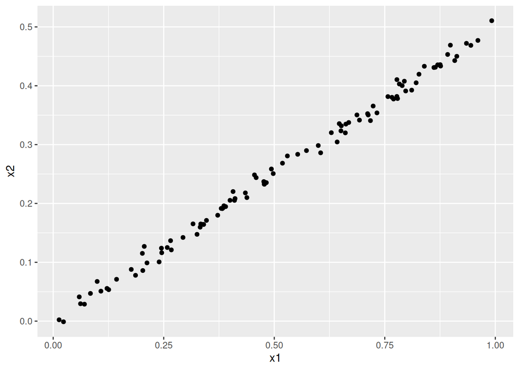

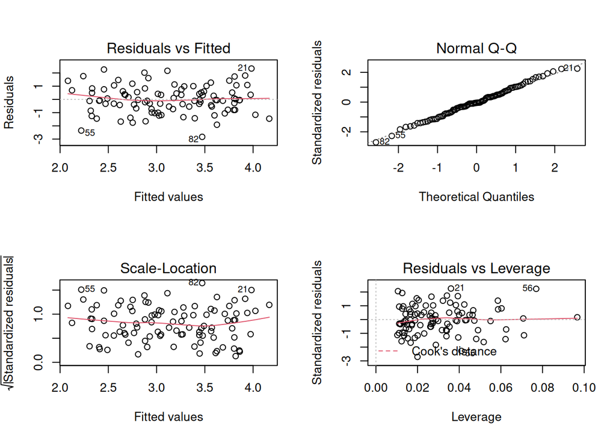

```
## $model
##
## Call:
## lm(formula = y ~ x1 + x2)
##
## Coefficients:
## (Intercept)           x1           x2
##       2.130       -1.754        7.397
##
##
## $s
## [1] 1.027705
##
## $summary
##
## Call:
## lm(formula = y ~ x1 + x2)
##
## Residuals:
##     Min      1Q  Median      3Q     Max
## -2.8311 -0.7273 -0.0537  0.6338  2.3359
##
## Coefficients:
##             Estimate Std. Error t value Pr(>|t|)
## (Intercept)   2.1305     0.2319   9.188 7.61e-15 ***
## x1           -1.7540     5.7178  -0.307    0.760
## x2            7.3967    11.3372   0.652    0.516
## ---
## Signif. codes:  0 '***' 0.001 '**' 0.01 '*' 0.05 '.' 0.1 ' ' 1
##
## Residual standard error: 1.056 on 97 degrees of freedom
## Multiple R-squared:  0.2051, Adjusted R-squared:  0.1887
## F-statistic: 12.51 on 2 and 97 DF,  p-value: 1.465e-05
##
##
## $plot
## NULL
```

```r
model_answer(lm(y ~ x1 + x2))
```

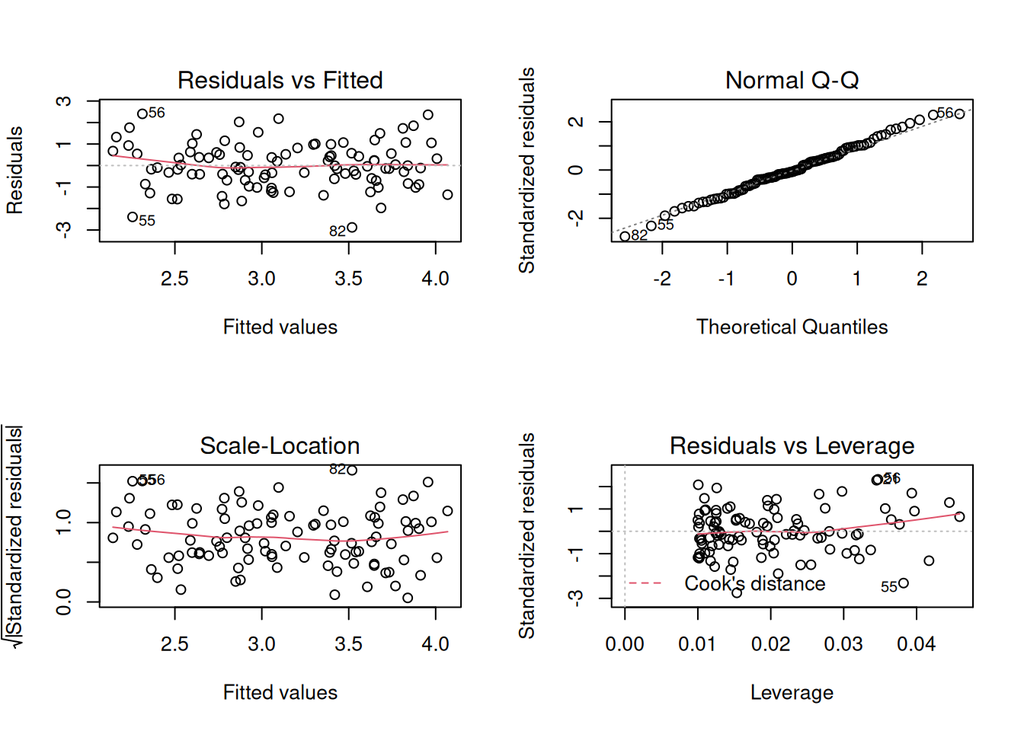

```
## $model
##
## Call:
## lm(formula = y ~ x1)
##
## Coefficients:
## (Intercept)           x1
##       2.117        1.967
##
##
## $s
## [1] 1.026196
##
## $summary
##
## Call:
## lm(formula = y ~ x1)
##
## Residuals:
##      Min       1Q   Median       3Q      Max
## -2.87789 -0.68357 -0.07517  0.61429  2.40388
##
## Coefficients:
##             Estimate Std. Error t value Pr(>|t|)
## (Intercept)   2.1172     0.2303   9.193 6.83e-15 ***
## x1            1.9675     0.3955   4.974 2.79e-06 ***
## ---
## Signif. codes:  0 '***' 0.001 '**' 0.01 '*' 0.05 '.' 0.1 ' ' 1
##
## Residual standard error: 1.053 on 98 degrees of freedom
## Multiple R-squared:  0.2016, Adjusted R-squared:  0.1934
## F-statistic: 24.74 on 1 and 98 DF,  p-value: 2.795e-06
##
##
## $plot
## NULL
```

```r
model_answer(lm(y ~ x1))
```

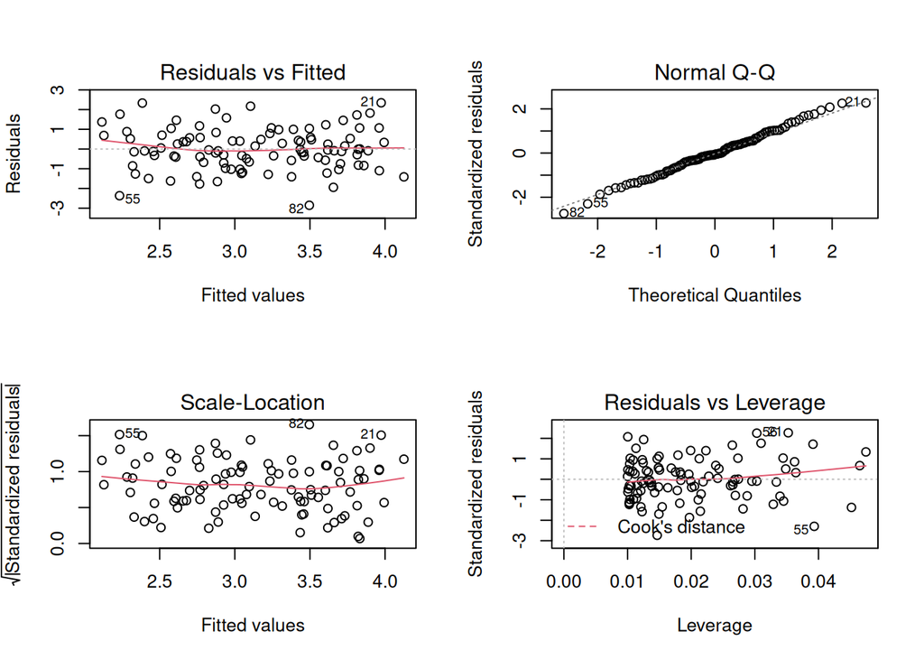

```
## $model
##
## Call:
## lm(formula = y ~ x2)
##
## Coefficients:
## (Intercept)           x2
##       2.120        3.927
##
##
## $s
## [1] 1.025322
##
## $summary
##
## Call:
## lm(formula = y ~ x2)
##
## Residuals:
##      Min       1Q   Median       3Q      Max
## -2.85470 -0.68465 -0.06898  0.60983  2.34499
##
## Coefficients:
##             Estimate Std. Error t value Pr(>|t|)
## (Intercept)   2.1199     0.2282   9.288 4.24e-15 ***
## x2            3.9273     0.7829   5.016 2.35e-06 ***
## ---
## Signif. codes:  0 '***' 0.001 '**' 0.01 '*' 0.05 '.' 0.1 ' ' 1
##
## Residual standard error: 1.051 on 98 degrees of freedom
## Multiple R-squared:  0.2043, Adjusted R-squared:  0.1962
## F-statistic: 25.16 on 1 and 98 DF,  p-value: 2.35e-06
##
##
## $plot
## NULL
```

```r
model_answer(lm(y ~ x2))
```

- The main difference is that when x1 and x2 are  
  included in a linear model they are not significant in describing y but individually they are significant.
- This is due to the almost perfect  
  multicollinearity involved between x1 and x2.
- Since x2 is essentially half of x1 the model with only x2 tries to compensate by setting the estimated value of x2 to be 2 times the true value of x1.
3. Use `x1`, `x2` and `y` from Exercise 2 and suppose that we obtain one additional observation, which was unfortunately mismeasured.

```r
x1 <- c(x1, 0.1)
x2 <- c(x2, 0.8)
y <- c(y, 6)
```

1. (4 pts) Re-fit the linear models from parts c, d and e of Exercise 1 using this new data. What effect does this new observation have on each of the models? In each model, is this observation an outlier? A high-leverage point? Both? Explain your answers.

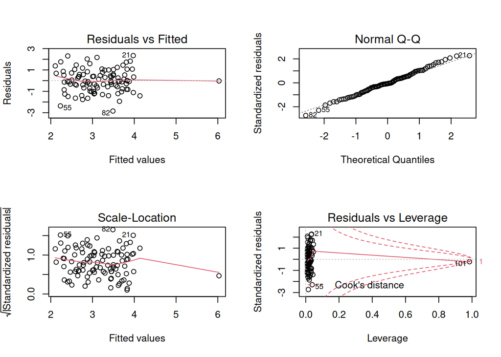

```
## $model
##
## Call:
## lm(formula = y ~ x1 + x2)
##
## Coefficients:
## (Intercept)           x1           x2
##      2.1250      -0.5183       4.9440
##
##
## $s
## [1] 1.025199
##
## $summary
##
## Call:
## lm(formula = y ~ x1 + x2)
##
## Residuals:
##      Min       1Q   Median       3Q      Max
## -2.84668 -0.67731 -0.05031  0.58942  2.34440
##
## Coefficients:
##             Estimate Std. Error t value Pr(>|t|)
## (Intercept)   2.1250     0.2294   9.265 4.77e-15 ***
## x1           -0.5183     0.7578  -0.684 0.495630
## x2            4.9440     1.4114   3.503 0.000695 ***
## ---
## Signif. codes:  0 '***' 0.001 '**' 0.01 '*' 0.05 '.' 0.1 ' ' 1
##
## Residual standard error: 1.051 on 98 degrees of freedom
## Multiple R-squared:  0.2495, Adjusted R-squared:  0.2341
## F-statistic: 16.29 on 2 and 98 DF,  p-value: 7.82e-07
##
##
## $plot
## NULL
```

```r
model_answer(lm(y ~ x1 + x2))
```

- In this model the new observation skews the parameter estimates far from their true values.
- This new observation is not an outlier because the residual  
  associated with that observation is close to 0 but it is a high leverage point based on Cook’s distance compared to other points.

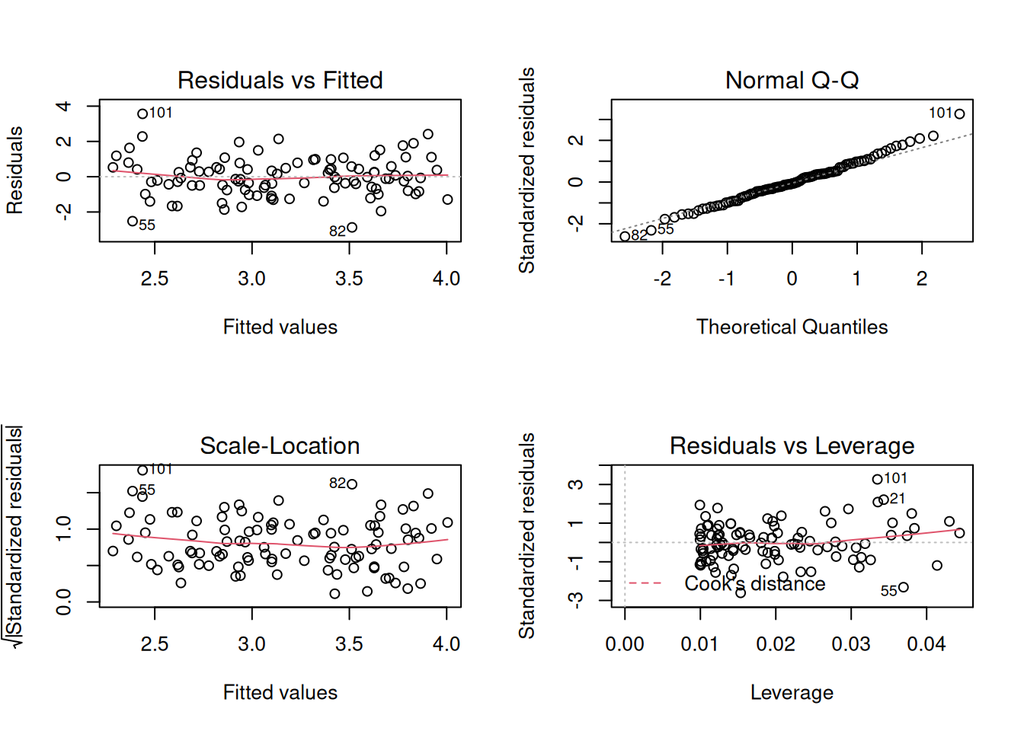

```
## $model
##
## Call:
## lm(formula = y ~ x1)
##
## Coefficients:
## (Intercept)           x1
##       2.262        1.757
##
##
## $s
## [1] 1.053206
##
## $summary
##
## Call:
## lm(formula = y ~ x1)
##
## Residuals:
##     Min      1Q  Median      3Q     Max
## -2.8726 -0.6826 -0.0747  0.5774  3.5626
##
## Coefficients:
##             Estimate Std. Error t value Pr(>|t|)
## (Intercept)   2.2616     0.2385   9.481 1.48e-15 ***
## x1            1.7575     0.4116   4.270 4.50e-05 ***
## ---
## Signif. codes:  0 '***' 0.001 '**' 0.01 '*' 0.05 '.' 0.1 ' ' 1
##
## Residual standard error: 1.109 on 99 degrees of freedom
## Multiple R-squared:  0.1555, Adjusted R-squared:  0.147
## F-statistic: 18.23 on 1 and 99 DF,  p-value: 4.498e-05
##
##
## $plot
## NULL
```

```r
model_answer(lm(y ~ x1))
```

- In this model the new observation skews the parameter estimate of x1 a little from its true value.
- This new observation is an outlier because the residual  
  associated with that observation is not close to 0 and it is not a high leverage point based on Cook’s distance compared to other points.

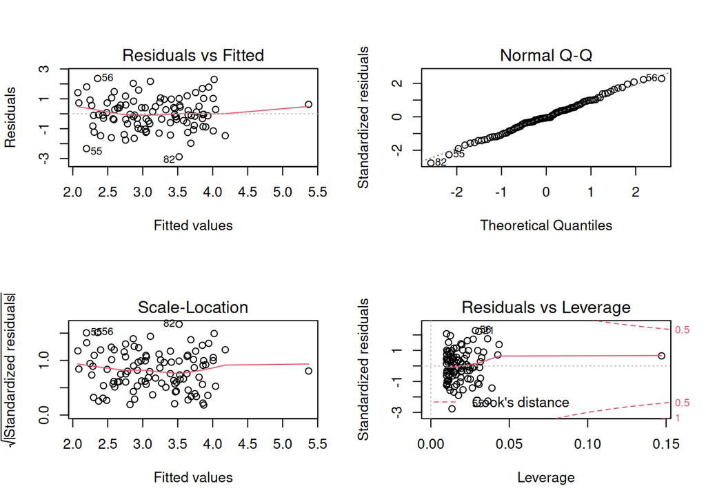

```
## $model
##
## Call:
## lm(formula = y ~ x2)
##
## Coefficients:
## (Intercept)           x2
##       2.077        4.116
##
##
## $s
## [1] 1.023818
##
## $summary
##
## Call:
## lm(formula = y ~ x2)
##
## Residuals:
##      Min       1Q   Median       3Q      Max
## -2.87832 -0.66757 -0.06731  0.62962  2.36205
##
## Coefficients:
##             Estimate Std. Error t value Pr(>|t|)
## (Intercept)   2.0773     0.2179   9.532 1.15e-15 ***
## x2            4.1164     0.7245   5.681 1.34e-07 ***
## ---
## Signif. codes:  0 '***' 0.001 '**' 0.01 '*' 0.05 '.' 0.1 ' ' 1
##
## Residual standard error: 1.048 on 99 degrees of freedom
## Multiple R-squared:  0.2459, Adjusted R-squared:  0.2383
## F-statistic: 32.28 on 1 and 99 DF,  p-value: 1.345e-07
##
##
## $plot
## NULL
```

```r
model_answer(lm(y ~ x2))
```

- In this model the new observation skews the parameter estimate of x2 far from its true value.
- This new observation is not an outlier because the residual  
  associated with that observation is close to 0 but it is a high leverage point based on Cook’s distance compared to other points.

# Multiple Linear Regression: Application

Load the `Carseats` data set contained in the `ISLR` library. `Carseats` is a simulated data set containing sales of child car seats at 400 different stores.

It contains the following variables:

- `Sales`: Unit sales (in thousands) at each location
- `CompPrice`: Price charged by competitor at each location
- `Income`: Community income level (in thousands of dollars)
- `Advertising`: Local advertising budget for company at each location (in thousands of dollars)
- `Population`: Population size in region (in thousands)
- `Price`: Price company charges for car seats at each site
- `ShelveLoc`: A factor with levels Bad, Good and Medium indicating the quality of the shelving location for the car seats at each site
- `Age`: Average age of the local population
- `Education`: Education level at each location
- `Urban`: A factor with levels No and Yes to indicate whether the store is in an urban or rural location
- `US`: A factor with levels No and Yes to indicate whether the store is in the US or not

For this Problem you will consider only Sales, Price, Income, Urban, ShelveLoc and Advertising.

```r
Carseats <- Carseats %>% select(
  Price,
  Sales,
  Income,
  Urban,
  ShelveLoc,
  Advertising
)
```

1. (2 points) Graphically explore the relationship between the six above variables (use the `ggpairs` function in the `GGally`). Comment on the plots: are they bivariate or univariate plots? Describe the plots (x-axis, y-axis, etc). What do you notice in the distribution of the variable `advertising`?

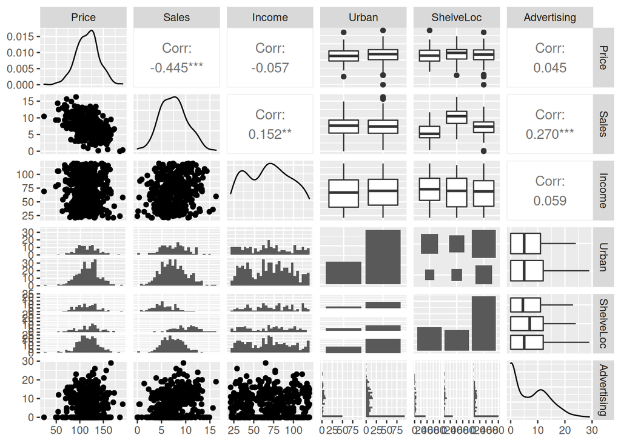

```r
ggpairs(Carseats)
```

- Univariate plots are on the diagonal.
- Bivariate plots are on the off-diagonal.
- The distribution of Advertising seems bimodal with most observations recieving a value between 0 and 20.
2. (2 points) Fit a multiple regression model to predict `Sales` using `Price`, `Income`, `Urban`, `Advertsing`, and `ShelveLoc`. Provide an interpretation of each coefficient in the model (be careful—some of the variables in the model are qualitative!).

```r
model <- lm(Sales ~ ., data = Carseats)
model %>% summary()
```

```
##
## Call:
## lm(formula = Sales ~ ., data = Carseats)
##
## Residuals:
##     Min      1Q  Median      3Q     Max
## -5.1957 -1.1420  0.0375  1.0624  4.1492
##
## Coefficients:
##                  Estimate Std. Error t value Pr(>|t|)
## (Intercept)     10.272928   0.533930  19.240  < 2e-16 ***
## Price           -0.057238   0.003690 -15.513  < 2e-16 ***
## Income           0.013643   0.003126   4.364 1.64e-05 ***
## UrbanYes         0.196891   0.191522   1.028    0.305
## ShelveLocGood    4.856543   0.260412  18.649  < 2e-16 ***
## ShelveLocMedium  1.911844   0.213703   8.946  < 2e-16 ***
## Advertising      0.105056   0.013141   7.994 1.47e-14 ***
## ---
## Signif. codes:  0 '***' 0.001 '**' 0.01 '*' 0.05 '.' 0.1 ' ' 1
##
## Residual standard error: 1.736 on 393 degrees of freedom
## Multiple R-squared:  0.6278, Adjusted R-squared:  0.6221
## F-statistic: 110.5 on 6 and 393 DF,  p-value: < 2.2e-16
```

- Price: With a one unit increase in Price, Sales on average will decrease by 0.06.
- Income: With a one unit increase in Income, Sales on average will increase by 0.01.
- UrbanYes: When Urban switches from no to yes, Sales on average will increase by 0.20.
- ShelveLocGood: When ShelveLoc switches from bad to good, Sales on average will increase by 4.86.
- ShelveLocMedium: When ShelveLoc switches from bad to medium,Sales on average will increase by 1.91.
- Advertising: With a one unit increase in Advertising, Sales on average will increase by 0.11.
3. (1 point) Write out the model in equation form, being careful to handle the qualitative variables properly (check this out: https://rmd4sci.njtierney.com/math to learn how to insert equations in Rmarkdown).

$$Sales = \beta_0 +
\beta_1(Price) +
\beta_2(Income) +
\beta_3(I(UrbanYes)) +
\beta_4(I(ShelveLocGood)) +
\beta_5(I(ShelveLocMedium)) +
\beta_6(Advertising)$$

4. (2 points) For which of the predictors can you reject the null hypothesis $H_0 : \beta_j = 0$? Moreover, which are the most significant variables?

```r
model %>% summary()
```

```
##
## Call:
## lm(formula = Sales ~ ., data = Carseats)
##
## Residuals:
##     Min      1Q  Median      3Q     Max
## -5.1957 -1.1420  0.0375  1.0624  4.1492
##
## Coefficients:
##                  Estimate Std. Error t value Pr(>|t|)
## (Intercept)     10.272928   0.533930  19.240  < 2e-16 ***
## Price           -0.057238   0.003690 -15.513  < 2e-16 ***
## Income           0.013643   0.003126   4.364 1.64e-05 ***
## UrbanYes         0.196891   0.191522   1.028    0.305
## ShelveLocGood    4.856543   0.260412  18.649  < 2e-16 ***
## ShelveLocMedium  1.911844   0.213703   8.946  < 2e-16 ***
## Advertising      0.105056   0.013141   7.994 1.47e-14 ***
## ---
## Signif. codes:  0 '***' 0.001 '**' 0.01 '*' 0.05 '.' 0.1 ' ' 1
##
## Residual standard error: 1.736 on 393 degrees of freedom
## Multiple R-squared:  0.6278, Adjusted R-squared:  0.6221
## F-statistic: 110.5 on 6 and 393 DF,  p-value: < 2.2e-16
```

- Here we can reject the tests for all predictors except for UrbanYes since the p-value for that test is greater than 0.01.
- Here we can’t say which variables are the most significant we can only say that we have evidence to reject the null hypothesis for these tests that have p-value less than 0.01.
5. (2 point) On the basis of your response to the previous question, fit a smaller model that only uses the predictors for which there is evidence of association with the outcome. Apply an F-test to compare the models and comment on the results.

```r
model_small <- lm(Sales ~ . - Urban, data = Carseats)
anova(model, model_small)
```

```
## Analysis of Variance Table
##
## Model 1: Sales ~ Price + Income + Urban + ShelveLoc + Advertising
## Model 2: Sales ~ (Price + Income + Urban + ShelveLoc + Advertising) -
##     Urban
##   Res.Df    RSS Df Sum of Sq      F Pr(>F)
## 1    393 1184.4
## 2    394 1187.6 -1   -3.1851 1.0569 0.3046
```

- Here the p-value of this F-test is greater than 0.01 so we fail to reject the null hypothesis and conclude that these two models are the same.
7. (3 points) Consider the reduced model in (e). Discuss whether the assumption of uncorrelated errors is justified. Plot the residuals to see whether there is heteroskedasticity present and whether the normality assumption holds.

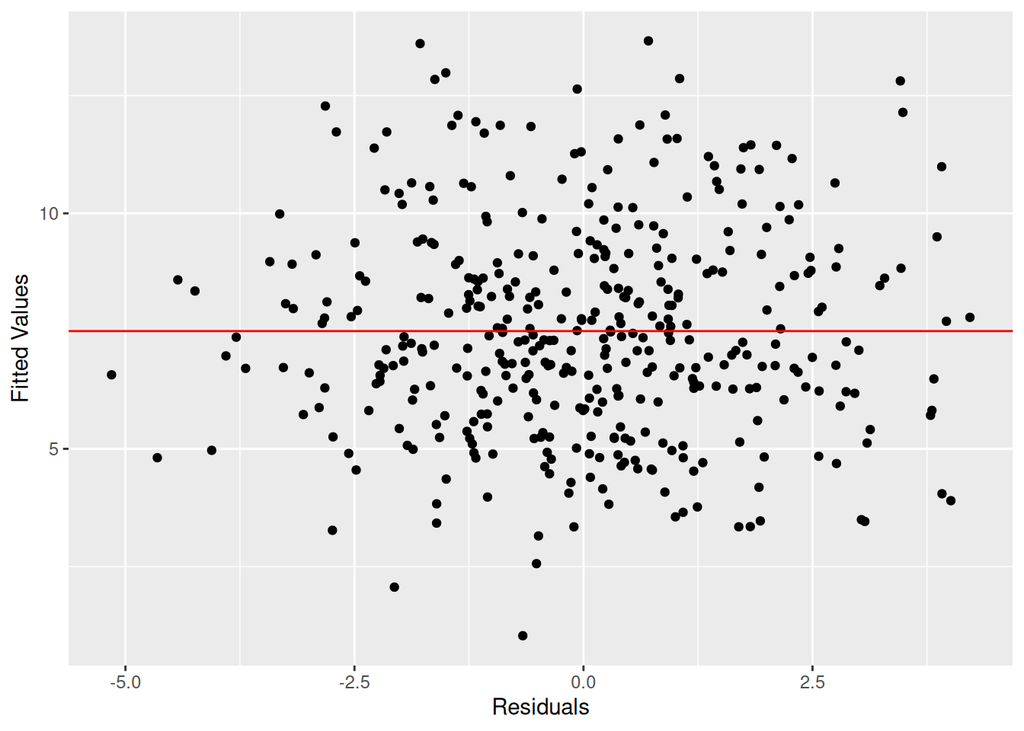

```r
res <- model_small$residuals
fitted <- model_small$fitted

res_data <- cbind(res, fitted) %>% as.data.frame()

ggplot(res_data, aes(x = res, y = fitted)) +
  geom_point() +
  geom_hline(aes(yintercept = 7.5), color = "red") +
  ylab("Fitted Values") +
  xlab("Residuals")
```

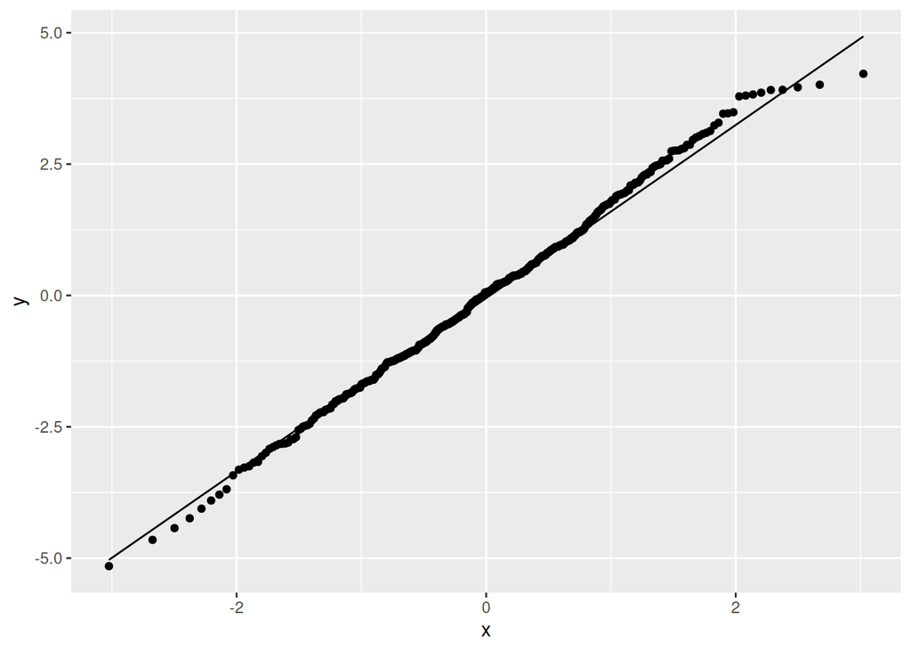

```r
ggplot(res_data, aes(sample = res)) +
  geom_qq() +
  geom_qq_line()
```

```r
Carseats <- Carseats %>% mutate(Advertising_levels = factor(case_when(
  Advertising == 0 ~ "None",
  Advertising < 10 ~ "Low",
  Advertising >= 10 & Advertising <= 20 ~ "Medium",
  TRUE ~ "High"
), levels = c("None", "Low", "Medium", "High")))


model_levels <- lm(Sales ~ . - Advertising - Urban, data = Carseats)

model_levels %>% summary()
```

```
##
## Call:
## lm(formula = Sales ~ . - Advertising - Urban, data = Carseats)
##
## Residuals:
##     Min      1Q  Median      3Q     Max
## -4.6104 -1.2200 -0.0158  1.1112  4.2213
##
## Coefficients:
##                           Estimate Std. Error t value Pr(>|t|)
## (Intercept)              10.390299   0.531940  19.533  < 2e-16 ***
## Price                    -0.057676   0.003758 -15.346  < 2e-16 ***
## Income                    0.014097   0.003152   4.472 1.02e-05 ***
## ShelveLocGood             4.877790   0.262608  18.574  < 2e-16 ***
## ShelveLocMedium           1.931826   0.215518   8.964  < 2e-16 ***
## Advertising_levelsLow     0.660774   0.225422   2.931  0.00357 **
## Advertising_levelsMedium  1.359952   0.208173   6.533 2.01e-10 ***
## Advertising_levelsHigh    3.023141   0.607320   4.978 9.65e-07 ***
## ---
## Signif. codes:  0 '***' 0.001 '**' 0.01 '*' 0.05 '.' 0.1 ' ' 1
##
## Residual standard error: 1.752 on 392 degrees of freedom
## Multiple R-squared:  0.6217, Adjusted R-squared:  0.615
## F-statistic: 92.03 on 7 and 392 DF,  p-value: < 2.2e-16
```

- Advertising_levelsLow: When Advertising_levels switches from None to Low, Sales on average will increase by 0.66.
- Advertising_levelsMedium: When Advertising_levels switches from None to Medium, Sales on average will increase by 1.36.
- Advertising_levelsHigh: When Advertising_levels switches from None to High, Sales on average will increase by 3.02.
- This result makes sense since the estimated coefficient for Advertising is 0.11, but the result of Advertising_levels shows that the effect does not linearly increase. Having an high advertising level increases sales more than having a medium or low  
  advertising level.